Skip to contents

# Customizing How Your Tables Look

Source: [`vignettes/facade.Rmd`](https://github.com/yng-me/tsg/blob/v0.2.0/vignettes/facade.Rmd)

```r
library(tsg)
library(dplyr)
```

`tsg` uses a **style** object (called a *facade*) to control how your tables look when exported: fonts, colours, borders, cell sizes, and more. You can:

- Use a **built-in style** out of the box,
- **Tweak a few settings** with `add_facade()`, or
- **Design your own style** by editing a YAML template.

The same style applies consistently to all output formats (Excel, HTML, PDF, Word).

## Using a built-in style

The package ships with thirteen named styles. Pass a name to any writer via the `facade` argument: a style looks the same in Excel, HTML, PDF and Word.

| Style name | Description |
| --- | --- |
| `"default"` | Clean, neutral; used automatically when no style is specified |
| `"yolo"` | Bolder colours and heavier formatting |
| `"apa"` | APA style: horizontal rules only, no fills, Times New Roman |
| `"booktabs"` | Thick top and bottom rules, a thin rule under the header, nothing else |
| `"striped"` | Coloured header band and banded body rows |
| `"gridded"` | Thin lines around every cell and a grey header, as in statistical yearbooks |
| `"minimal"` | No borders or fills, light grey rules between rows; suits web and dashboards |
| `"financial"` | Dark blue header, thin grey grid and a bold last row, as in business reports |
| `"nyt"` | Editorial: bold header over a thick rule, no vertical lines, light banding |
| `"jama"` | Medical-journal: horizontal rules only, bold sans-serif header and first column |
| `"dark"` | Light text on a dark background |
| `"pastel"` | Soft blue header and group titles |
| `"census"` | Official statistics: grey header, bold group titles, small italic notes |

```r
tbl <- person_record |>
  generate_frequency(sex)

write_xlsx(tbl, path = "booktabs.xlsx", facade = "booktabs")
write_html(tbl, path = "booktabs.html", facade = "booktabs")
write_docx(tbl, path = "booktabs.docx", facade = "booktabs")

# The default style is used when you leave out `facade`
write_xlsx(tbl, path = "default.xlsx")
```

Only `"default"` differs a little between formats (for example, Word uses a smaller font). Every other style is laid over that format’s default. Settings that only mean something in a spreadsheet, such as row heights and column widths, are ignored outside Excel.

Here is each style in Excel (a screenshot of the sheet `write_xlsx()` writes) and in HTML (built with `as_gt()`, which returns the styled `gt` table for your own Quarto or R Markdown documents):

#### `default`

**Excel**

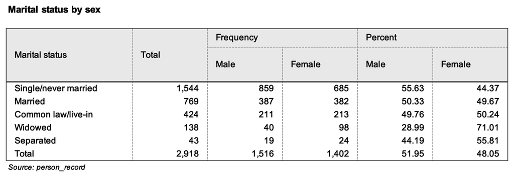

**HTML**

Marital status by sex

| Marital status | Total | Frequency Male | Frequency Female | Percent Male | Percent Female |
| --- | --- | --- | --- | --- | --- |
| Single/never married | 1,544 | 859 | 685 | 55.63 | 44.37 |
| Married | 769 | 387 | 382 | 50.33 | 49.67 |
| Common law/live-in | 424 | 211 | 213 | 49.76 | 50.24 |
| Widowed | 138 | 40 | 98 | 28.99 | 71.01 |
| Separated | 43 | 19 | 24 | 44.19 | 55.81 |
| Total | 2,918 | 1,516 | 1,402 | 51.95 | 48.05 |

Source: person_record

#### `yolo`

**Excel**

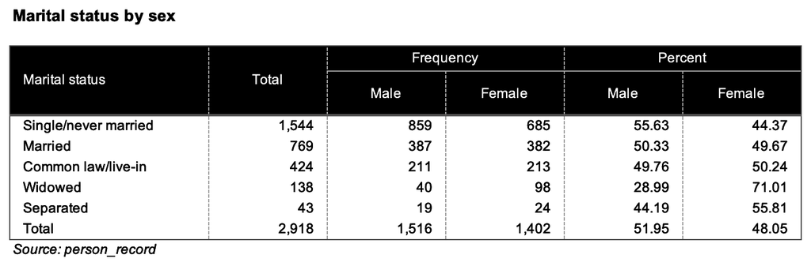

**HTML**

Marital status by sex

| Marital status | Total | Frequency Male | Frequency Female | Percent Male | Percent Female |
| --- | --- | --- | --- | --- | --- |
| Single/never married | 1,544 | 859 | 685 | 55.63 | 44.37 |
| Married | 769 | 387 | 382 | 50.33 | 49.67 |
| Common law/live-in | 424 | 211 | 213 | 49.76 | 50.24 |
| Widowed | 138 | 40 | 98 | 28.99 | 71.01 |
| Separated | 43 | 19 | 24 | 44.19 | 55.81 |
| Total | 2,918 | 1,516 | 1,402 | 51.95 | 48.05 |

Source: person_record

#### `apa`

**Excel**

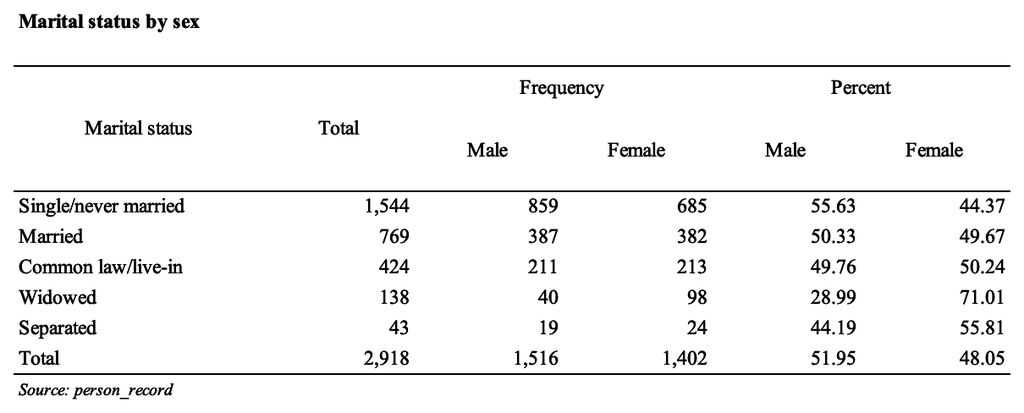

**HTML**

Marital status by sex

| Marital status | Total | Frequency Male | Frequency Female | Percent Male | Percent Female |
| --- | --- | --- | --- | --- | --- |
| Single/never married | 1,544 | 859 | 685 | 55.63 | 44.37 |
| Married | 769 | 387 | 382 | 50.33 | 49.67 |
| Common law/live-in | 424 | 211 | 213 | 49.76 | 50.24 |
| Widowed | 138 | 40 | 98 | 28.99 | 71.01 |
| Separated | 43 | 19 | 24 | 44.19 | 55.81 |
| Total | 2,918 | 1,516 | 1,402 | 51.95 | 48.05 |

Source: person_record

#### `booktabs`

**Excel**

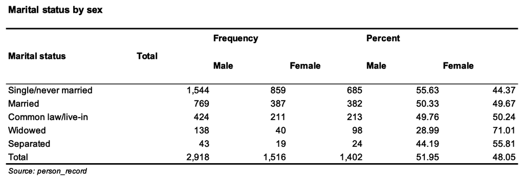

**HTML**

Marital status by sex

| Marital status | Total | Frequency Male | Frequency Female | Percent Male | Percent Female |
| --- | --- | --- | --- | --- | --- |
| Single/never married | 1,544 | 859 | 685 | 55.63 | 44.37 |
| Married | 769 | 387 | 382 | 50.33 | 49.67 |
| Common law/live-in | 424 | 211 | 213 | 49.76 | 50.24 |
| Widowed | 138 | 40 | 98 | 28.99 | 71.01 |
| Separated | 43 | 19 | 24 | 44.19 | 55.81 |
| Total | 2,918 | 1,516 | 1,402 | 51.95 | 48.05 |

Source: person_record

#### `striped`

**Excel**

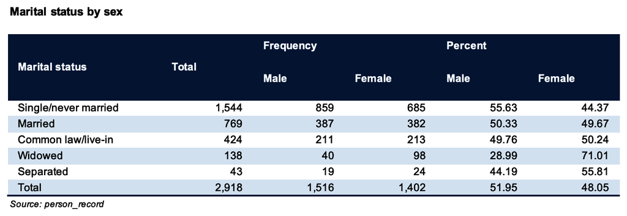

**HTML**

Marital status by sex

| Marital status | Total | Frequency Male | Frequency Female | Percent Male | Percent Female |
| --- | --- | --- | --- | --- | --- |
| Single/never married | 1,544 | 859 | 685 | 55.63 | 44.37 |
| Married | 769 | 387 | 382 | 50.33 | 49.67 |
| Common law/live-in | 424 | 211 | 213 | 49.76 | 50.24 |
| Widowed | 138 | 40 | 98 | 28.99 | 71.01 |
| Separated | 43 | 19 | 24 | 44.19 | 55.81 |
| Total | 2,918 | 1,516 | 1,402 | 51.95 | 48.05 |

Source: person_record

#### `gridded`

**Excel**

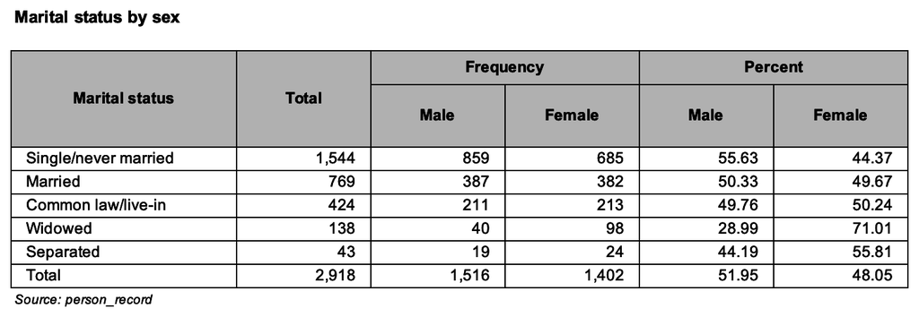

**HTML**

Marital status by sex

| Marital status | Total | Frequency Male | Frequency Female | Percent Male | Percent Female |
| --- | --- | --- | --- | --- | --- |
| Single/never married | 1,544 | 859 | 685 | 55.63 | 44.37 |
| Married | 769 | 387 | 382 | 50.33 | 49.67 |
| Common law/live-in | 424 | 211 | 213 | 49.76 | 50.24 |
| Widowed | 138 | 40 | 98 | 28.99 | 71.01 |
| Separated | 43 | 19 | 24 | 44.19 | 55.81 |
| Total | 2,918 | 1,516 | 1,402 | 51.95 | 48.05 |

Source: person_record

#### `minimal`

**Excel**

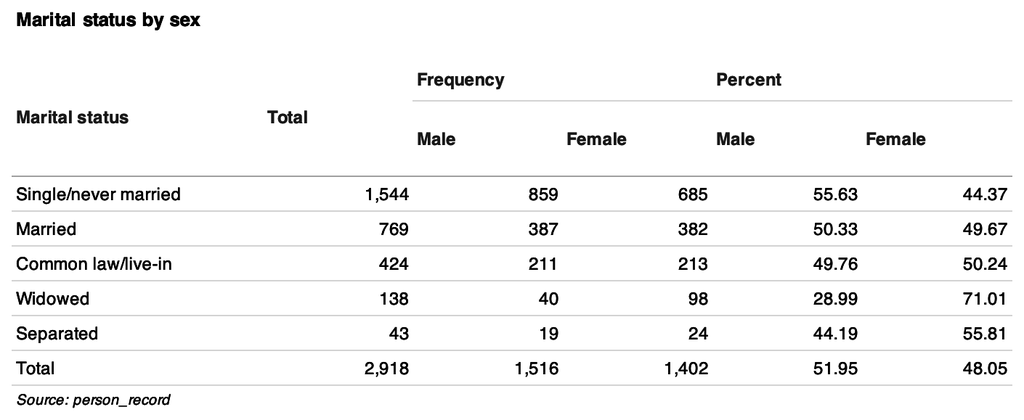

**HTML**

Marital status by sex

| Marital status | Total | Frequency Male | Frequency Female | Percent Male | Percent Female |
| --- | --- | --- | --- | --- | --- |
| Single/never married | 1,544 | 859 | 685 | 55.63 | 44.37 |
| Married | 769 | 387 | 382 | 50.33 | 49.67 |
| Common law/live-in | 424 | 211 | 213 | 49.76 | 50.24 |
| Widowed | 138 | 40 | 98 | 28.99 | 71.01 |
| Separated | 43 | 19 | 24 | 44.19 | 55.81 |
| Total | 2,918 | 1,516 | 1,402 | 51.95 | 48.05 |

Source: person_record

#### `financial`

**Excel**

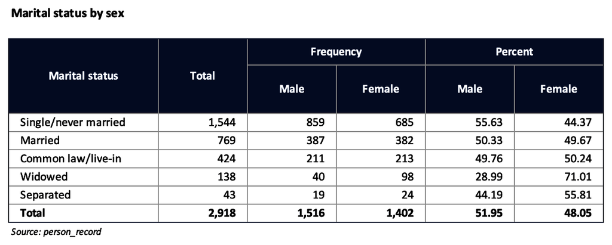

**HTML**

Marital status by sex

| Marital status | Total | Frequency Male | Frequency Female | Percent Male | Percent Female |
| --- | --- | --- | --- | --- | --- |
| Single/never married | 1,544 | 859 | 685 | 55.63 | 44.37 |
| Married | 769 | 387 | 382 | 50.33 | 49.67 |
| Common law/live-in | 424 | 211 | 213 | 49.76 | 50.24 |
| Widowed | 138 | 40 | 98 | 28.99 | 71.01 |
| Separated | 43 | 19 | 24 | 44.19 | 55.81 |
| Total | 2,918 | 1,516 | 1,402 | 51.95 | 48.05 |

Source: person_record

#### `nyt`

**Excel**

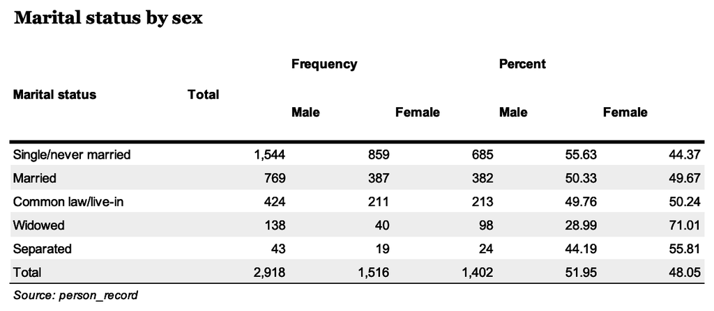

**HTML**

Marital status by sex

| Marital status | Total | Frequency Male | Frequency Female | Percent Male | Percent Female |
| --- | --- | --- | --- | --- | --- |
| Single/never married | 1,544 | 859 | 685 | 55.63 | 44.37 |
| Married | 769 | 387 | 382 | 50.33 | 49.67 |
| Common law/live-in | 424 | 211 | 213 | 49.76 | 50.24 |
| Widowed | 138 | 40 | 98 | 28.99 | 71.01 |
| Separated | 43 | 19 | 24 | 44.19 | 55.81 |
| Total | 2,918 | 1,516 | 1,402 | 51.95 | 48.05 |

Source: person_record

#### `jama`

**Excel**

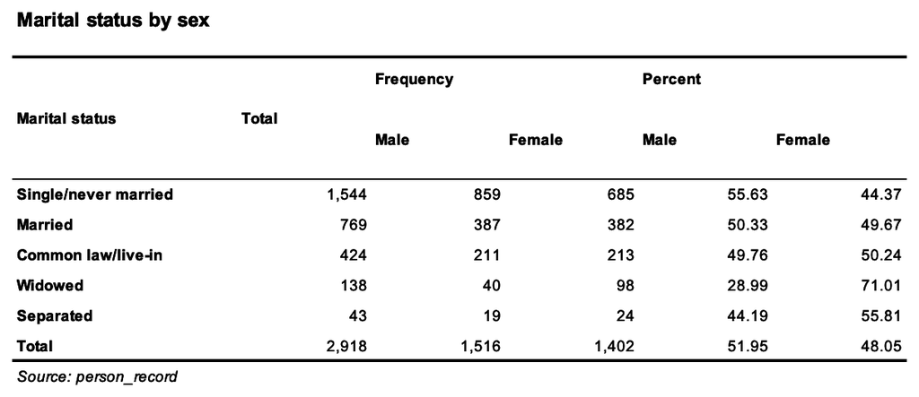

**HTML**

Marital status by sex

| Marital status | Total | Frequency Male | Frequency Female | Percent Male | Percent Female |
| --- | --- | --- | --- | --- | --- |
| Single/never married | 1,544 | 859 | 685 | 55.63 | 44.37 |
| Married | 769 | 387 | 382 | 50.33 | 49.67 |
| Common law/live-in | 424 | 211 | 213 | 49.76 | 50.24 |
| Widowed | 138 | 40 | 98 | 28.99 | 71.01 |
| Separated | 43 | 19 | 24 | 44.19 | 55.81 |
| Total | 2,918 | 1,516 | 1,402 | 51.95 | 48.05 |

Source: person_record

#### `dark`

**Excel**

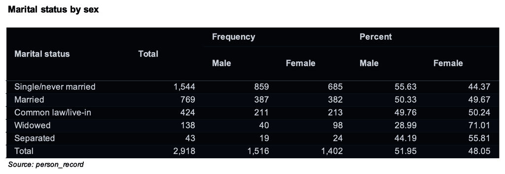

**HTML**

Marital status by sex

| Marital status | Total | Frequency Male | Frequency Female | Percent Male | Percent Female |
| --- | --- | --- | --- | --- | --- |
| Single/never married | 1,544 | 859 | 685 | 55.63 | 44.37 |
| Married | 769 | 387 | 382 | 50.33 | 49.67 |
| Common law/live-in | 424 | 211 | 213 | 49.76 | 50.24 |
| Widowed | 138 | 40 | 98 | 28.99 | 71.01 |
| Separated | 43 | 19 | 24 | 44.19 | 55.81 |
| Total | 2,918 | 1,516 | 1,402 | 51.95 | 48.05 |

Source: person_record

#### `pastel`

**Excel**

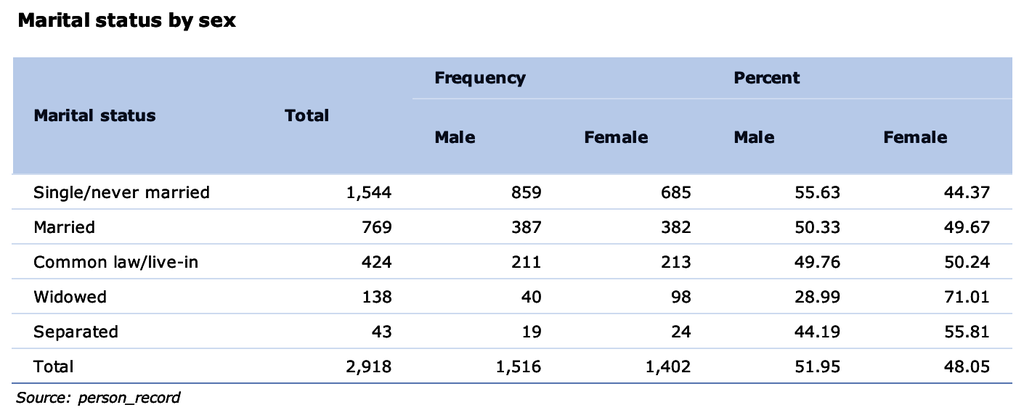

**HTML**

Marital status by sex

| Marital status | Total | Frequency Male | Frequency Female | Percent Male | Percent Female |
| --- | --- | --- | --- | --- | --- |
| Single/never married | 1,544 | 859 | 685 | 55.63 | 44.37 |
| Married | 769 | 387 | 382 | 50.33 | 49.67 |
| Common law/live-in | 424 | 211 | 213 | 49.76 | 50.24 |
| Widowed | 138 | 40 | 98 | 28.99 | 71.01 |
| Separated | 43 | 19 | 24 | 44.19 | 55.81 |
| Total | 2,918 | 1,516 | 1,402 | 51.95 | 48.05 |

Source: person_record

#### `census`

**Excel**

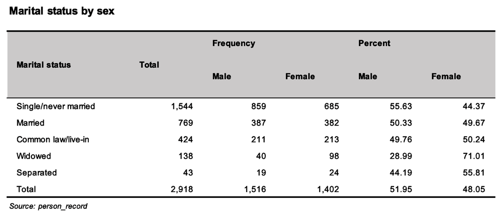

**HTML**

Marital status by sex

| Marital status | Total | Frequency Male | Frequency Female | Percent Male | Percent Female |
| --- | --- | --- | --- | --- | --- |
| Single/never married | 1,544 | 859 | 685 | 55.63 | 44.37 |
| Married | 769 | 387 | 382 | 50.33 | 49.67 |
| Common law/live-in | 424 | 211 | 213 | 49.76 | 50.24 |
| Widowed | 138 | 40 | 98 | 28.99 | 71.01 |
| Separated | 43 | 19 | 24 | 44.19 | 55.81 |
| Total | 2,918 | 1,516 | 1,402 | 51.95 | 48.05 |

Source: person_record

## Tweaking a few settings with `add_facade()`

`add_facade()` lets you override individual style settings without replacing the whole style. Call it in your pipeline before `write_*()`.

Style settings use a two-part name: **which part of the table** `.` **what to change**. For example:

- `header.fgFill`: fill colour of the column header
- `body.fontSize`: font size of the data cells
- `table.offsetRow`: blank rows above the table (Excel only)

```r
person_record |>
  generate_frequency(sex) |>
  add_facade(
    table.offsetRow = 2,
    table.offsetCol = 1
  )
```

```
#> # A tibble: 3 × 3
#>   category   frequency percent
#>   <int+lbl>      <int>   <dbl>
#> 1 1 [Male]        1516    52.0
#> 2 2 [Female]      1402    48.0
#> 3 0 [Total]       2918   100
```

### Common tweaks

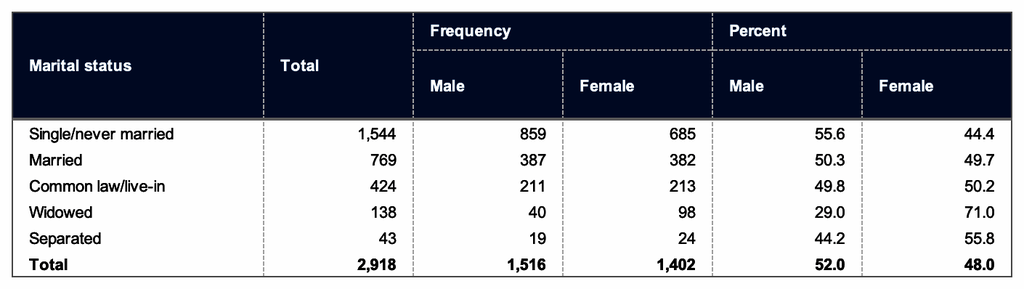

```r
person_record |>
  generate_crosstab(marital_status, sex) |>
  add_facade(
    # Move the table down 2 rows and right 1 column (Excel only)
    table.offsetRow = 2,
    table.offsetCol = 1,
    # Round numbers to 1 decimal place
    table.decimalPrecision = 1,
    # Make the last row (usually Total) bold
    table.lastRowBold = TRUE,
    # Header background colour and white text
    header.fgFill = "#003366",
    header.fontColour = "#FFFFFF",
    header.textDecoration = "bold",
    # Data cell font size
    body.fontSize = 11
  ) |>
  write_xlsx(path = "styled-table.xlsx")
```

> **Good to know:** A few settings only mean something in a spreadsheet: row heights (`height`), column widths (`width`, `table.widthOffset`), `table.offsetRow`, `table.offsetCol`, `table.gridLines`, `table.tabColour`, `table.locked`, `table.hidden`, `indent` and `wrapText`. HTML, Word and PDF ignore them, so you can attach them once and export to any format without changing anything.

### Borders

Borders take three settings per part: `border` (which sides: `"top"`, `"bottom"`, `"left"`, `"right"`), `borderColour` and `borderStyle`. Border styles use the Excel names in every format; HTML, PDF and Word draw the nearest line:

| `borderStyle` | HTML / PDF | Word |
| --- | --- | --- |
| `"thin"`, `"hair"` | 1px solid | 0.75pt solid |
| `"medium"` | 2px solid | 1.5pt solid |
| `"thick"` | 3px solid | 2.25pt solid |
| `"dashed"`, `"mediumDashed"` | 1px / 2px dashed | 0.75pt / 1.5pt dashed |
| `"dotted"` | 1px dotted | 0.75pt dotted |
| `"double"` | 3px double | 2.25pt double |
| `"dashDot"`, `"dashDotDot"`, `"slantDashDot"` and their `medium` forms | dashed | dashed |

The parts with borders are `body` (every data cell), `header` (every header cell), `spanner` (the upper header rows of a crosstab), `border_header` (the rule under the header) and `border_outer` (the outline around header and body). `body.bandFill` shades every other data row.

```r
person_record |>
  generate_crosstab(marital_status, sex) |>
  add_facade(
    border_outer.border = c("top", "bottom"),
    border_outer.borderStyle = "medium",
    border_header.border = "bottom",
    border_header.borderStyle = "thin",
    body.bandFill = "#F2F2F2"
  ) |>
  write_html(path = "rules.html")
```

### Applying the same tweaks across formats

Once you attach style overrides with `add_facade()`, those overrides are carried with the table object and applied to whichever format you export to. You only need to style the table once.

```r
styled_tbl <- person_record |>
  generate_frequency(sex) |>
  add_table_title("Distribution by Sex") |>
  add_source_note("Source: Survey 2024") |>
  add_facade(
    header.fgFill = "#003366",
    header.fontColour = "#FFFFFF",
    header.textDecoration = "bold",
    body.fontSize = 11,
    table.lastRowBold = TRUE
  )

write_xlsx(styled_tbl, path = "table.xlsx")
write_html(styled_tbl, path = "table.html")
write_pdf(styled_tbl, path = "table.pdf")
write_docx(styled_tbl, path = "table.docx")
```

## Making your own style file

For full control, generate a starter YAML file, edit it to your taste, and load it back in.

### Step 1: generate the template

```r
generate_template("my-style.yaml", template = "facade")
```

### Step 2: edit the file

Open `my-style.yaml` in any text editor. It looks like this:

```yaml
table.fontName: 'Arial'
table.fontSize: 12
table.offsetRow: 0
table.offsetCol: 0
table.decimalPrecision: 2
table.lastRowBold: false
table.width: 14

header.fgFill: ~          # ~ leaves the setting off
header.fontColour: ~
header.textDecoration: ~
header.height: 28

body.fontSize: ~
body.bgFill: ~
body.numFmt: "###0"
body.height: 20

title.fontSize: 13
title.textDecoration: "bold"
title.height: 24

source_note.fontSize: 10
source_note.textDecoration: "italic"
```

Change any value you like. A setting set to `~` is turned off; a setting you delete from the file comes from the default facade.

> **Tip:** `get_tsg_facade()` also accepts `.json` file paths if you prefer JSON over YAML.

### Step 3: use your style

Pass the file’s path as the `facade` of any writer:

```r
tbl <- person_record |>
  generate_frequency(sex)

write_xlsx(tbl, path = "custom-styled.xlsx", facade = "my-style.yaml")
write_docx(tbl, path = "custom-styled.docx", facade = "my-style.yaml")
```

## Programmatic style overrides

If you need to build style settings dynamically (for example, in a loop or from a config), keep them in a named list and pass it to `add_facade()` with `do.call()`, or pass the list as the `facade` of a writer.

```r
overrides <- list(
  table.offsetRow = 3,
  header.fgFill = "#2E4057",
  header.fontColour = "#FFFFFF",
  body.fontSize = 11
)

do.call(
  add_facade,
  c(list(data = person_record |> generate_frequency(sex)), overrides)
)
```

```
#> # A tibble: 3 × 3
#>   category   frequency percent
#>   <int+lbl>      <int>   <dbl>
#> 1 1 [Male]        1516    52.0
#> 2 2 [Female]      1402    48.0
#> 3 0 [Total]       2918   100
```

## Style property reference

The table below lists every setting supported by each section of the table.

| Section | Properties |
| --- | --- |
| table | fontName, fontSize, fontColour, bgFill, fgFill, halign, valign, textDecoration, wrapText, indent, border, borderColour, borderStyle, width |
| title | fontName, fontSize, fontColour, bgFill, fgFill, halign, valign, textDecoration, wrapText, indent, border, borderColour, borderStyle, height |
| subtitle | fontName, fontSize, fontColour, bgFill, fgFill, halign, valign, textDecoration, wrapText, indent, border, borderColour, borderStyle, height |
| header | fontName, fontSize, fontColour, bgFill, fgFill, halign, valign, textDecoration, wrapText, indent, border, borderColour, borderStyle, height |
| spanner | fontName, fontSize, fontColour, bgFill, fgFill, halign, valign, textDecoration, wrapText, indent, border, borderColour, borderStyle, height |
| body | fontName, fontSize, fontColour, bgFill, fgFill, halign, valign, textDecoration, wrapText, indent, border, borderColour, borderStyle, numFmt, height |
| col_first | fontName, fontSize, fontColour, bgFill, fgFill, halign, valign, textDecoration, wrapText, indent, border, borderColour, borderStyle, numFmt, height, width |
| col_last | fontName, fontSize, fontColour, bgFill, fgFill, halign, valign, textDecoration, wrapText, indent, border, borderColour, borderStyle, numFmt, height, width |
| row_group | fontName, fontSize, fontColour, bgFill, fgFill, halign, valign, textDecoration, wrapText, indent, border, borderColour, borderStyle, height, width |
| sub_group | fontName, fontSize, fontColour, bgFill, fgFill, halign, valign, textDecoration, wrapText, indent, border, borderColour, borderStyle, height |
| source_note | fontName, fontSize, fontColour, bgFill, fgFill, halign, valign, textDecoration, wrapText, indent, border, borderColour, borderStyle, height |
| footnotes | fontName, fontSize, fontColour, bgFill, fgFill, halign, valign, textDecoration, wrapText, indent, border, borderColour, borderStyle, height |

### Table-level settings (full list)

| Setting | What it does | Excel | HTML | Word |
| --- | --- | --- | --- | --- |
| `table.fontName` | Default font family | ✓ | ✓ | ✓ |
| `table.fontSize` | Default font size | ✓ | ✓ | ✓ |
| `table.fontColour` | Default font colour | ✓ | ✓ | ✓ |
| `table.bgFill` | Table background colour | ✓ | ✓ | ✓ |
| `table.decimalPrecision` | Decimal places for numbers | ✓ | ✓ | ✓ |
| `table.decimalCols` | Which columns get decimal formatting | ✓ | ✓ | ✓ |
| `table.lastRowBold` | Make the last row bold | ✓ | ✓ | ✓ |
| `table.offsetRow` | Blank rows above the table | ✓ |  |  |
| `table.offsetCol` | Blank columns to the left | ✓ |  |  |
| `table.gridLines` | Show worksheet grid lines | ✓ |  |  |
| `table.tabColour` | Excel worksheet tab colour | ✓ |  |  |
| `table.locked` | Lock the worksheet | ✓ |  |  |
| `table.hidden` | Hide the worksheet | ✓ |  |  |
| `table.width` | Column width | ✓ |  |  |
| `table.widthOffset` | Extra width added to auto-sized columns | ✓ |  |  |

### Colour values

`fgFill` is the fill colour of a cell. `bgFill` is the background of a fill pattern in Excel, so it shows only behind a pattern; HTML and Word use it when `fgFill` is not set. All `fontColour`, `bgFill`, and `fgFill` settings accept:

- Hex colour codes: `"#003366"`
- Named R colours: `"navy"`
- `~` (in YAML) or `NULL` (in R) to use the inherited default

### Section names

| Section | What it styles |
| --- | --- |
| `table` | Global table settings |
| `title` | Title row above the table |
| `subtitle` | Subtitle row |
| `header` | Column header row(s) |
| `spanner` | Grouped header rows in cross-tabulations |
| `body` | Data rows |
| `col_first` | First (category) column |
| `col_last` | Last column |
| `row_group` | Group header rows |
| `sub_group` | Sub-group rows |
| `source_note` | Source note row below the table |
| `footnotes` | Footnote rows |
| `border_header` | Border under the header |
| `border_outer` | Outer border around the table |
| `border_bottom` | Bottom border row height |